# Final Project Summary

Tiasia Saunders

2025-04-13

In an R Markdown document, provide a summary of your final project. Include a link to the source data that you have compiled in your GitHub repository,

## Final Project Summary

This project explores how news media covered diversity, equity, and inclusion (DEI) topics during the first month of Donald Trump’s presidency, focusing on the differences between **domestic and international** newspaper coverage. More specifically, articles that discussed Trump’s adminsitration dismantling federal DEI programs. I compiled a set of news articles using Nexis Uni, then cleaned and processed them for text analysis. In the Nexis Uni site, I narrowed the articles with Date: 01/20/25-02/20/25, Keyword: Diversity & Inclusion, Data Type: Newspaper Articles, and Language: English. This returned a total of 1916 articles to work with in my analysis.

## Description of Data

The dataset includes articles published in the first month of Trump’s 2025 presidency (Jan2025-Feb2025) containing keywords related to DEI and the Trump administration. It includes variables like publication name, publication country, date, full article text, and a binary variable that I added toindicate whether the article is **domestic** or **international**, also a column of politically_leaning (which I haven’t started to incorporate into my data analysis yet. Right now I am focusing on it from a international versue domestic standpoint, before looking at it through a political lens.

## Content Analysis Plan

I plan to conduct a content analysis to compare how DEI-related issues were framed across domestic and international newspapers. I’ve created a **preliminary codebook**in my topic_modeling assignment to identify topic themes such as: - **Corporate DEI policies** - **Education-related DEI** - **Trump’s national politics** - **Administrative orders** - **Campus media coverage**

These categories are being developed based on the most frequent bigrams and common narrative themes. Preliminary coding involves using keyword matching and bigram frequency analysis to map patterns of coverage.

## Unit of Analysis

The unit of analysis is an individual news article. The content analysis will focus on three components within each article: - The **publication_location** - The **dom_vs_intl** - The **political_leaning**

### Codebook (Preliminary Version)

| Code | Definition | Example |
| --- | --- | --- |
| Tone_Positive | Article uses language reflecting hope, resolution, or positive outcomes | “Protesters call for reform, urge peaceful change” |
| Tone_Negative | Article uses alarmist or fear-inducing language | “Mob storms the Capitol in unprecedented violence” |
| Dom_vs_intl | Classifies the article as Domestic or International | Domestic (e.g. NYT), International (e.g. BBC) |
| Political_Affiliation | Implies alignment with a political ideology or party | “Left-wing activists confront right-wing group” |

> _Note: Codebook is subject to refinement following further testing

### Preliminary Work

-creating binary columns to perform content analysis on - Term frequency and bigram analysis were used to supplement theme identification, using packages such as `tidytext`, `dplyr`, and `ggplot2` in R. - Graphs were made to show the distribution of outlets via location (domestic vs international) and to show the top 20 bigrams

## Sample of the Data

```r
# Load libraries
library(tidyverse)
library(tidytext)
library(lubridate)
library(stringr)
library(ggplot2)
library(dplyr)

# Load the data
#dei_articles <- read_csv("trump_dei_final_index.csv")
library(googledrive)
library(rio)
```

# Import Data from Google Drive

```r
googledrive::drive_deauth()
temp_file <- tempfile()
drive_download(as_id("1fexSMTg_wJOpyh_XCuc_3_2CP_FGS_tB"), path = temp_file)
```

```
## File downloaded:
```

```
## • 'trump_dei_final_index.csv' <id: 1fexSMTg_wJOpyh_XCuc_3_2CP_FGS_tB>
```

```
## Saved locally as:
```

```
## • '/var/folders/6w/sgrmrps15mdf4l6v1k79k5bc0000gn/T//RtmpBCkJ4B/file2a264e155fe'
```

```r
#the file id is in the URL for your trump_dei_final_index.csv. which you get from clicking "Share on the Google Drive version and copying the link: https://drive.google.com/file/d/1fexSMTg_wJOpyh_XCuc_3_2CP_FGS_tB/view?usp=sharing
#https://drive.google.com/file/d/1fexSMTg_wJOpyh_XCuc_3_2CP_FGS_tB/view?usp=sharing
#your file id: "1fexSMTg_wJOpyh_XCuc_3_2CP_FGS_tB"'

# Then import the downloaded file from your hard drive
dei_articles <- rio::import(temp_file, format = "csv") # If you know the file format, specify it explicitly..."csv" or "xlsx", "txt", etc.
```

##Number of columns and rows

```r
print(paste0("This dataset has ", nrow(dei_articles), " rows and ", ncol(dei_articles), " columns."))
```

```
## [1] "This dataset has 1916 rows and 25 columns."
```

##Descriptive Statistics

```r
summary(dei_articles)
```

```
##        V1            title           published_date       publication_location
##  Min.   :   1.0   Length:1916        Min.   :2025-01-20   Length:1916
##  1st Qu.: 479.8   Class :character   1st Qu.:2025-01-28   Class :character
##  Median : 958.5   Mode  :character   Median :2025-02-03   Mode  :character
##  Mean   : 958.5                      Mean   :2025-02-03
##  3rd Qu.:1437.2                      3rd Qu.:2025-02-11
##  Max.   :1916.0                      Max.   :2025-02-20
##  publication_4      publication_type_5     length          section
##  Length:1916        Length:1916        Min.   :   40.0   Length:1916
##  Class :character   Class :character   1st Qu.:  472.0   Class :character
##  Mode  :character   Mode  :character   Median :  690.5   Mode  :character
##                                        Mean   :  829.7
##                                        3rd Qu.:  980.0
##                                        Max.   :11304.0
##    word_count       countries            byline          agg_copyright
##  Min.   :   40.0   Length:1916        Length:1916        Mode:logical
##  1st Qu.:  472.0   Class :character   Class :character   NA's:1916
##  Median :  690.5   Mode  :character   Mode  :character
##  Mean   :  829.7
##  3rd Qu.:  980.0
##  Max.   :11304.0
##      cite             company            headline            hlead
##  Length:1916        Length:1916        Length:1916        Length:1916
##  Class :character   Class :character   Class :character   Class :character
##  Mode  :character   Mode  :character   Mode  :character   Mode  :character
##
##
##
##  publication_16     publication_type_17 pub_copyright    show
##  Length:1916        Length:1916         Mode:logical   Mode:logical
##  Class :character   Class :character    NA's:1916      NA's:1916
##  Mode  :character   Mode  :character
##
##
##
##    term          ticker           index             filename
##  Mode:logical   Mode:logical   Length:1916        Length:1916
##  NA's:1916      NA's:1916      Class :character   Class :character
##                                Mode  :character   Mode  :character
##
##
##
##    filepath
##  Length:1916
##  Class :character
##  Mode  :character
##
##
##
```

#frequency count for each category and their location

```r
table(dei_articles$dom_vs_intl)
```

```
## < table of extent 0 >
```

```r
table(dei_articles$publication_location)
```

```
##
##           Arizona        California       Connecticut Dist. of Columbia
##                 3                27                 9               107
##           Florida           Georgia             Idaho          Illinois
##                10                 9                 1                14
##     International              Iowa            Kansas         Louisiana
##              1133                 5                 1                 1
##             Maine          Maryland         Minnesota          Missouri
##                18                36                21                 4
##     New Hampshire        New Mexico          New York      North Dakota
##                 1                 5                15                 7
##              Ohio            Oregon      Pennsylvania      U.S. Federal
##                 8                 1                66               388
##              Utah          Virginia        Washington     West Virginia
##                 8                 4                 6                 2
##         Wisconsin
##                 6
```

##adding categorizing columns such as dom_vs_intl to indicate whether the article is international or domestic and policial_leaning to identify blue and red states that the articles came out of

```r
dei_articles <- dei_articles |>
 #mutating a new column to indicate whether the pub location is international or domestic

mutate(dom_vs_intl = case_when (
  publication_location == "International" ~ "INTL",
  publication_location != "International" ~ "US",
  TRUE ~ NA
)) |>
## mutating a new column to indicate whether the state is blue or red
mutate(political_leaning = case_when (
  publication_location == "Maryland" ~ "Blue",
  publication_location == "Washington"~ "Blue",
  publication_location =="California" ~ "Blue",
  publication_location == "Colorado" ~ "Blue",
  publication_location == "New Mexico"~ "Blue",
  publication_location == "Minnesota" ~ "Blue",
  publication_location == "Illinois" ~ "Blue",
  publication_location == "Virginia" ~ "Blue",
  publication_location == "Maryland" ~ "Blue",
  publication_location == "Deleware" ~ "Blue",
  publication_location == "New Jersey" ~ "Blue",
  publication_location == "New York" ~ "Blue",
  publication_location == "Vermont" ~ "Blue",
  publication_location == "Rhode Island" ~ "Blue",
  publication_location == "Connecticut" ~ "Blue",
  publication_location == "Maine" ~ "Blue",
  publication_location == "New Hampishire" ~ "Blue",
  publication_location == "District of Columbia" ~ "Blue",
  publication_location == "International" ~ "NA",

  TRUE ~ "Red"

))
```

## GGplot of the articles over time (1 month)

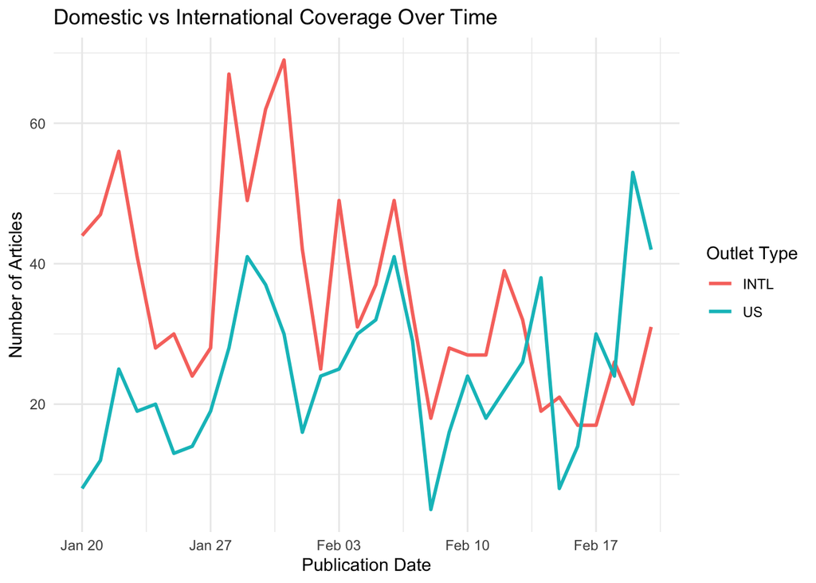

```r
df_time <- dei_articles |>
  count(published_date, dom_vs_intl)

ggplot(df_time, aes(x = published_date, y = n, color = dom_vs_intl)) +
  geom_line(size = 1) +
  labs(
    title = "Domestic vs International Coverage Over Time",
    x = "Publication Date",
    y = "Number of Articles",
    color = "Outlet Type"
  ) +
  theme_minimal()
```

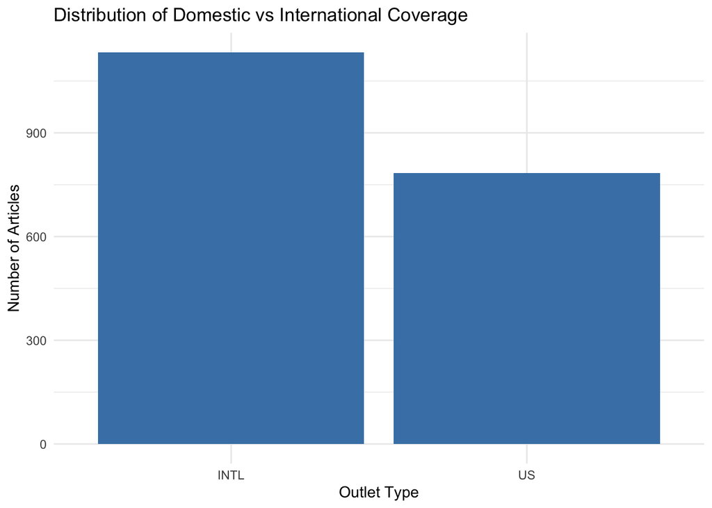

```r
ggplot(dei_articles, aes(x = dom_vs_intl)) +
  geom_bar(fill = "steelblue") +
  labs(
    title = "Distribution of Domestic vs International Coverage",
    x = "Outlet Type",
    y = "Number of Articles"
  ) +
  theme_minimal()
```

## Bigrams:

```r
stories <- str_replace_all(dei_articles$hlead, "- ", "")
stories_df <- tibble(stories,)

# unnest includes lower, punct removal

stories_tokenized <- stories_df |>
  unnest_tokens(word,stories)

stories_tokenized
```

```
## # A tibble: 201,142 × 1
##    word
##    <chr>
##  1 what
##  2 is
##  3 dei
##  4 why
##  5 did
##  6 trump
##  7 fire
##  8 all
##  9 dei
## 10 workers
## # ℹ 201,132 more rows
```

#Remove stopwords and count the words

```r
stories_tokenized <- stories_tokenized |>
  anti_join(stop_words, by = c("word" = "word"))
```

# Word Count

```r
story_word_ct <- stories_tokenized %>%
  count(word, sort=TRUE)
```

# Create Bigrams

```r
bigrams <- stories_df %>%
  unnest_tokens(bigram, stories, token="ngrams", n=2)

bigrams
```

```
## # A tibble: 199,226 × 1
##    bigram
##    <chr>
##  1 what is
##  2 is dei
##  3 dei why
##  4 why did
##  5 did trump
##  6 trump fire
##  7 fire all
##  8 all dei
##  9 dei workers
## 10 workers on
## # ℹ 199,216 more rows
```

```r
#Filter out stop words.

bigrams1 <- bigrams %>%
  separate(bigram, c("word1", "word2"), sep = " ")

filtered_bigrams <- bigrams1 %>%
  filter(!word1 %in% stop_words$word) %>%
  filter(!word2 %in% stop_words$word) |>
    filter(!is.na(word1)) |>
     filter(!is.na(word2))

counted_bigrams <- filtered_bigrams %>%
  count(word1, word2, sort = TRUE)
```

##top twenty bigrams

```r
top_bigrams <- counted_bigrams |>
  arrange(desc(n), word1, word2) |>
  head(20)
```

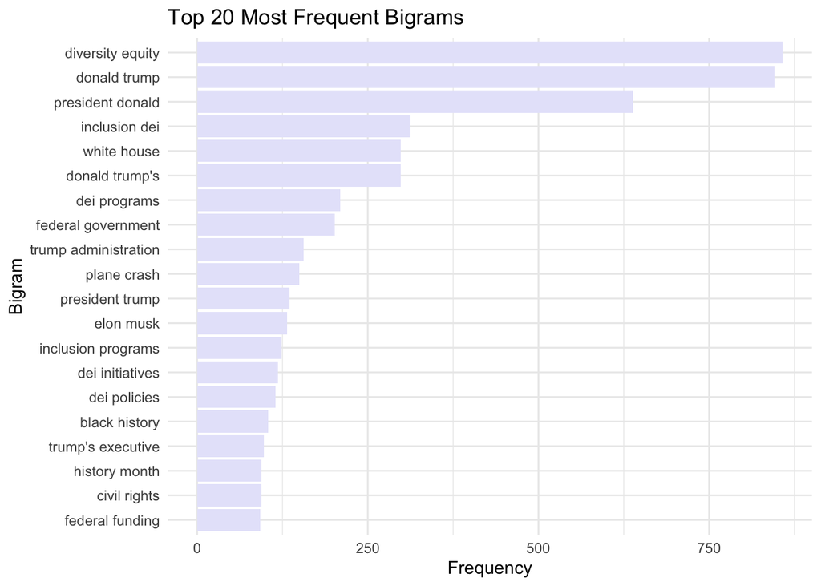

```r
# Combine the bigram into one string for labeling
top_bigrams <- counted_bigrams |>
  arrange(desc(n), word1, word2) |>
  head(20) |>
  mutate(bigram = paste(word1, word2))

# Plot
ggplot(top_bigrams, aes(x = reorder(bigram, n), y = n)) +
  geom_col(fill = "lavender") +
  coord_flip() +
  labs(
    title = "Top 20 Most Frequent Bigrams",
    x = "Bigram",
    y = "Frequency"
  ) +
  theme_minimal()
```

###do more work girlypop